```
From: https://github.com/ksatola
Version: 0.1.0
```

# Model - PM2.5 - AutoRegressive Moving Average (ARMA)

## Contents

- AutoRegressive Moving Average (ARMA) modelling
- Hourly forecast
  - Load hourly data
  - Modelling (train, predict/validate)
- Daily forecast
  - Load daily data
  - Modelling

```python
%load_ext autoreload
```

```python
%autoreload 2
```

```python
import sys
sys.path.insert(0, '../src')
```

```python
import warnings
warnings.filterwarnings('ignore')

from statsmodels.tools.sm_exceptions import ConvergenceWarning, ValueWarning
warnings.simplefilter('ignore', ConvergenceWarning)
warnings.simplefilter('ignore', ValueWarning)
```

```python
import pandas as pd
import numpy as np

from statsmodels.tsa.statespace.sarimax import SARIMAX

import matplotlib.pyplot as plt
%matplotlib inline
```

```python
from model import (
    get_pm25_data_for_modelling,
    get_best_arima_params_for_time_series,
    split_df_for_ts_modelling_offset,
    predict_ts,
    fit_model
)

from measure import (
    get_rmse,
    walk_forward_ts_model_validation2,
    get_mean_folds_rmse_for_n_prediction_points,
    prepare_data_for_visualization
)

from plot import (
    visualize_results,
    plot_ts_corr
)

from utils import (
    get_datetime_identifier
)

from logger import logger
```

```python
model_name = 'ARMA'
```

## Autoregressive Moving Average (ARMA) modelling

An ARMA model, or Autoregressive Moving Average model, is used to describe weakly stationary stochastic time series in terms of two polynomials. The first of these polynomials is for autoregression (AR), the second for the moving average (MA):

```
AR(p) uses previous values of the dependent variable to make predictions.
MA(q) uses the series mean and previous errors to make predictions.
```

Often this model is referred to as the ARMA(p,q) model; where:

```
p is the order of the autoregressive polynomial,
q is the order of the moving average polynomial.
```

The equation is given by:

[figure not shown]

Where:

```
φ = the autoregressive model’s parameters,
θ = the moving average model’s parameters.
c = a constant,
ε = error terms (white noise).
```

### The Time Series ARMA Forecasting Process

- Perform simple time series EDA
  - Missing observations
  - Data centricity and spread
  - Outliers, trend and frequency changes -> stationarity, detrending?
  - Data distribution fit into Gaussian distribution -> power transforms?
- Perform TS Decomposition, take residuals for the modeling
  - Test stationarity of residuals
  - Check if residuals is white noise
- Split the residuals dataset into train, test sets

## Load hourly data

```python
dfh = get_pm25_data_for_modelling('ts', 'h')
dfh.head()
```

```
common.py | 42 | get_pm25_data_for_modelling | 10-Jun-20 17:00:55 | INFO: Dataframe loaded: /Users/ksatola/Documents/git/air-pollution/agh/data/dfpm25_2008-2018_hourly.hdf
common.py | 43 | get_pm25_data_for_modelling | 10-Jun-20 17:00:55 | INFO: Dataframe size: (96388, 1)
```

| Datetime | pm25 |
| --- | --- |
| 2008-01-01 01:00:00 | 92.0 |
| 2008-01-01 02:00:00 | 81.0 |
| 2008-01-01 03:00:00 | 73.0 |
| 2008-01-01 04:00:00 | 60.5 |
| 2008-01-01 05:00:00 | 61.0 |

```python
df = dfh.copy()
```

```python
# Define first past/future cutoff point in time offset (1 year of data)
cut_off_offset = 365*24 # for hourly data
#cut_off_offset = 365 # for daily data

# Predict for X points
n_pred_points = 24 # for hourly data
#n_pred_points = 7 # for daily data

# https://pandas.pydata.org/pandas-docs/stable/user_guide/timeseries.html#offset-aliases
period = 'H' # for hourly data
#period = 'D' # for daily data
```

### Train test split

```python
# Create train / test datasets (with the offset of cut_off_offset datapoints from the end)
# period=None because we need index to be DatetimeIndex not PeriodIndex for SARIMAX
df_train, df_test = split_df_for_ts_modelling_offset(data=df, cut_off_offset=cut_off_offset, period=None)
```

```
common.py | 159 | split_df_for_ts_modelling_offset | 10-Jun-20 17:00:59 | INFO: Observations: 96388
common.py | 160 | split_df_for_ts_modelling_offset | 10-Jun-20 17:00:59 | INFO: Training Observations: 87627
common.py | 161 | split_df_for_ts_modelling_offset | 10-Jun-20 17:00:59 | INFO: Testing Observations: 8760
common.py | 163 | split_df_for_ts_modelling_offset | 10-Jun-20 17:00:59 | INFO: (96388, 1), (87627, 1), (8760, 1), 96387
```

## Modelling (train, predict/validate)

In statistical time series models, fitting the model means estimating its paraneters. In case of AR model, the only parameter to estimate is number of autocorrelated lags.

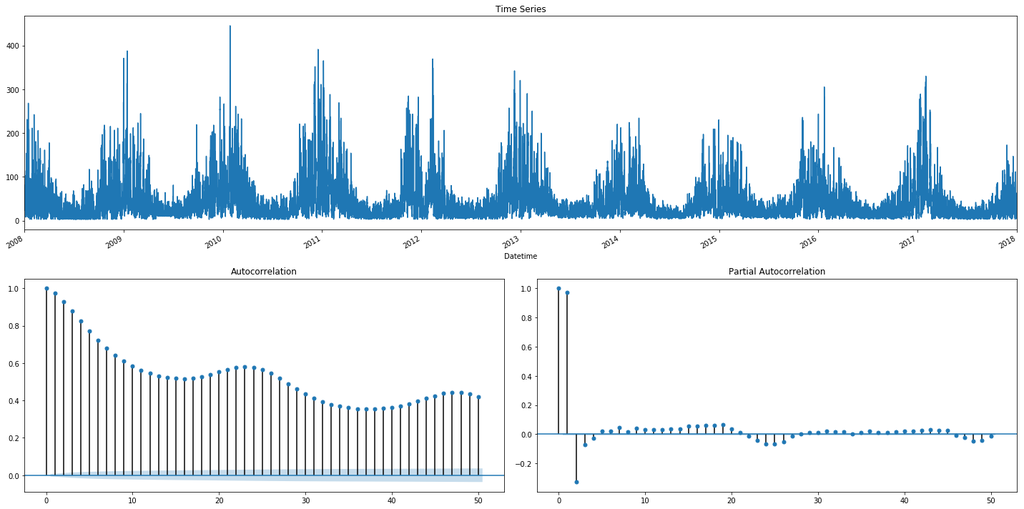

```python
plot_ts_corr(df_train['pm25'])
```

```python
%%time
# Find best parameters (grid-search)
best_results = get_best_arima_params_for_time_series(data=df_train,
                                                     seasonal=False,
                                                     max_param_range_p=5,
                                                     max_param_range_d=2,
                                                     max_param_range_q=5)
```

```python
SARIMAX(0, 0, 0) - AIC:950035.119919657
SARIMAX(0, 0, 1) - AIC:843344.0396508672
SARIMAX(0, 0, 2) - AIC:772685.05307077
SARIMAX(0, 0, 3) - AIC:726435.4649042541
SARIMAX(0, 0, 4) - AIC:699267.5669061132
SARIMAX(0, 0, 5) - AIC:679220.6801305263
SARIMAX(0, 1, 0) - AIC:637526.5016885484
SARIMAX(0, 1, 1) - AIC:629960.3879021691
SARIMAX(0, 1, 2) - AIC:628846.653452479
SARIMAX(0, 1, 3) - AIC:628480.5779072419
SARIMAX(0, 1, 4) - AIC:628474.1076286844
SARIMAX(0, 1, 5) - AIC:628470.5808444964
SARIMAX(1, 0, 2) - AIC:627752.667749163
SARIMAX(1, 0, 3) - AIC:627233.671710295
SARIMAX(1, 0, 4) - AIC:627176.4310598889
SARIMAX(1, 0, 5) - AIC:627165.0028807595
SARIMAX(1, 1, 3) - AIC:626081.1199039271
SARIMAX(1, 1, 5) - AIC:625019.2327505194
SARIMAX(2, 1, 2) - AIC:624910.203481772
SARIMAX(2, 1, 3) - AIC:624873.0049011122
SARIMAX(2, 1, 4) - AIC:624854.8941542685
SARIMAX(3, 0, 3) - AIC:624793.04465309
SARIMAX(5, 0, 2) - AIC:624767.846410448
SARIMAX(5, 0, 3) - AIC:624676.504781964
Best model is ARIMA(5, 0, 3) with AIC of 624676.504781964
CPU times: user 2h 35min 14s, sys: 15min 17s, total: 2h 50min 32s
Wall time: 49min 34s
```

```python
%%time
# Train the model -> find best parameters
p = 5 # (AR)
d = 0 # differencing
q = 3 # (MA)
model = SARIMAX(endog=df_train, order=(p, d, q))
model_fitted = model.fit()
```

```
CPU times: user 2min 50s, sys: 21.5 s, total: 3min 12s
Wall time: 49.9 s
```

```python
model_fitted
```

```
<statsmodels.tsa.statespace.sarimax.SARIMAXResultsWrapper at 0x1306bf2d0>
```

```python
# Estimated parameters
print(model_fitted.summary())
```

```
                               SARIMAX Results
==============================================================================
Dep. Variable:                   pm25   No. Observations:                87627
Model:               SARIMAX(5, 0, 3)   Log Likelihood             -312329.252
Date:                Wed, 10 Jun 2020   AIC                         624676.505
Time:                        17:02:56   BIC                         624760.932
Sample:                             0   HQIC                        624702.280
                              - 87627
Covariance Type:                  opg
==============================================================================
                 coef    std err          z      P>|z|      [0.025      0.975]
------------------------------------------------------------------------------
ar.L1          2.0136      0.005    400.786      0.000       2.004       2.023
ar.L2         -0.2409      0.007    -33.035      0.000      -0.255      -0.227
ar.L3         -1.8299      0.004   -470.172      0.000      -1.838      -1.822
ar.L4          1.2337      0.007    169.704      0.000       1.219       1.248
ar.L5         -0.1773      0.003    -68.282      0.000      -0.182      -0.172
ma.L1         -0.7607      0.005   -160.186      0.000      -0.770      -0.751
ma.L2         -0.9631      0.001   -762.177      0.000      -0.966      -0.961
ma.L3          0.7940      0.005    167.908      0.000       0.785       0.803
sigma2        72.8297      0.106    685.286      0.000      72.621      73.038
===================================================================================
Ljung-Box (Q):                     2521.41   Jarque-Bera (JB):           1723030.18
Prob(Q):                              0.00   Prob(JB):                         0.00
Heteroskedasticity (H):               0.57   Skew:                            -0.38
Prob(H) (two-sided):                  0.00   Kurtosis:                        24.71
===================================================================================

Warnings:
[1] Covariance matrix calculated using the outer product of gradients (complex-step).
```

```python
# True parameters
print(f'The coefficients of the model are:\n {model_fitted.params}')
```

```
The coefficients of the model are:
 ar.L1      2.013583
ar.L2     -0.240854
ar.L3     -1.829906
ar.L4      1.233712
ar.L5     -0.177316
ma.L1     -0.760678
ma.L2     -0.963136
ma.L3      0.794044
sigma2    72.829697
dtype: float64
```

```python
print(f'The residual errors during training of the model are:\n {model_fitted.resid}')
```

```
The residual errors during training of the model are:
 Datetime
2008-01-01 02:00:00    81.000000
2008-01-01 03:00:00    -6.809136
2008-01-01 04:00:00    -8.558594
2008-01-01 05:00:00     5.870893
2008-01-01 06:00:00     7.735716
                         ...
2017-12-31 20:00:00    10.367140
2017-12-31 21:00:00    -1.927225
2017-12-31 22:00:00    21.830414
2017-12-31 23:00:00   -17.753752
2018-01-01 00:00:00    -7.457803
Length: 87627, dtype: float64
```

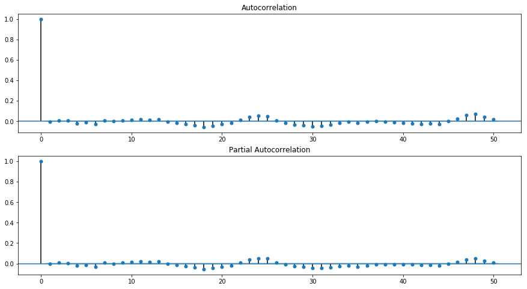

```python
# Evaluate model quality
import statsmodels.api as sm
res = model_fitted.resid
fig,ax = plt.subplots(2,1,figsize=(15,8))
fig = sm.graphics.tsa.plot_acf(res, lags=50, ax=ax[0])
fig = sm.graphics.tsa.plot_pacf(res, lags=50, ax=ax[1])
plt.show();
```

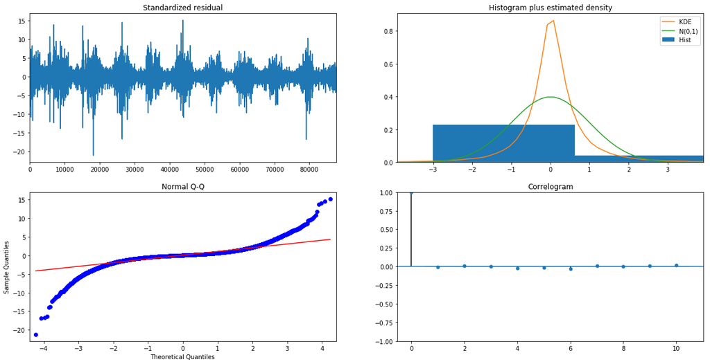

```python
# Evaluate model quality
model_fitted.plot_diagnostics(figsize=(20, 10))
plt.show();
```

ARMA model alone fits not vary bad for hourly data but it does not capture the multilayer seasonality (yearly, weekly, daily) in data. There is still way for improvement (if possible).

```python
%%time
# Validate result on test
# Creates 365*24*24 models for hourly data, or 365*7 models for hourly data

fold_results = walk_forward_ts_model_validation2(data=df,
                                                 col_name='pm25',
                                                 model_type='ARMA',
                                                 p=p,
                                                 d=d,
                                                 q=q,
                                                 cut_off_offset=cut_off_offset,
                                                 n_pred_points=n_pred_points,
                                                 n_folds=-1,
                                                 period=period)
print(len(fold_results))
print(fold_results[0])
```

[output not shown]

### Serialize output data

```python
from joblib import dump, load

timestamp = get_datetime_identifier("%Y-%m-%d_%H-%M-%S")

path = f'results/pm25_ts_{model_name}_results_h_{timestamp}.joblib'

#dump(fold_results, path)
fold_results = load(path)
print(len(fold_results))
print(fold_results[0])
```

[output not shown]

### Calculate and visualize results

```python
%%time
# Returns a list of mean folds RMSE for n_pred_points (starting at 1 point forecast)
res = get_mean_folds_rmse_for_n_prediction_points(fold_results=fold_results, n_pred_points=n_pred_points)
res
```

[output not shown]

```python
print(res)
```

```python
# Show forecasts for n-th point in the future
show_n_points_of_forecasts = [1, 12, 24] # for hourly data
#show_n_points_of_forecasts = [1, 3, 7] # for daily data

# Used to zoom the plots (date ranges shown in the plots)
# for hourly data
start_end_dates = [('2018-01-01', '2019-01-01'), ('2018-02-01', '2018-03-01'), ('2018-06-01', '2018-07-01')]
# for daily data
#start_end_dates = [('2018-01-01', '2019-01-01'), ('2018-02-01', '2018-04-01'), ('2018-06-01', '2018-08-01')]

# Type of plot
# 0 -> plot_observed_vs_predicted
# 1 -> plot_observed_vs_predicted_with_error
plot_types = [0, 1, 1]

# File names for plots (format png will be used, do not add .png extension)
base_file_path = f'images/pm25_obs_vs_pred_365_h_ts_{model_name}' # for hourly data
#base_file_path = f'images/pm25_obs_vs_pred_365_d_ts_{model_name}' # for daily data
```

```python
fold_results[0].index
```

```python
# We need to convert to datetime index for plotting
# https://stackoverflow.com/questions/29394730/converting-periodindex-to-datetimeindex
for i in range(0, len(fold_results)):
    if not isinstance(fold_results[i].index, pd.DatetimeIndex):
        fold_results[i].index = fold_results[i].index.to_timestamp()
```

```python
fold_results[0].index
```

```python
visualize_results(show_n_points_of_forecasts=show_n_points_of_forecasts,
                   start_end_dates=start_end_dates,
                   plot_types=plot_types,
                   base_file_path=base_file_path,
                   fold_results=fold_results,
                   n_pred_points=n_pred_points,
                   cut_off_offset=cut_off_offset,
                   model_name=model_name,
                timestamp=timestamp)
```

[output not shown]

## Load daily data

```python
dfd = get_pm25_data_for_modelling('ts', 'd')
dfd.head()
```

```
common.py | 42 | get_pm25_data_for_modelling | 10-Jun-20 13:55:01 | INFO: Dataframe loaded: /Users/ksatola/Documents/git/air-pollution/agh/data/dfpm25_2008-2018_daily.hdf
common.py | 43 | get_pm25_data_for_modelling | 10-Jun-20 13:55:01 | INFO: Dataframe size: (4019, 1)
```

| Datetime | pm25 |
| --- | --- |
| 2008-01-01 | 53.586957 |
| 2008-01-02 | 30.958333 |
| 2008-01-03 | 46.104167 |
| 2008-01-04 | 42.979167 |
| 2008-01-05 | 57.312500 |

```python
df = dfd.copy()
```

```python
# Define first past/future cutoff point in time offset (1 year of data)
#cut_off_offset = 365*24 # for hourly data
cut_off_offset = 365 # for daily data

# Predict for X points
#n_pred_points = 24 # for hourly data
n_pred_points = 7 # for daily data

# https://pandas.pydata.org/pandas-docs/stable/user_guide/timeseries.html#offset-aliases
#period = 'H' # for hourly data
period = 'D' # for daily data
```

### Train test split

```python
# Create train / test datasets (with the offset of cut_off_offset datapoints from the end)
# period=None because we need index to be DatetimeIndex not PeriodIndex for SARIMAX
df_train, df_test = split_df_for_ts_modelling_offset(data=df, cut_off_offset=cut_off_offset, period=None)
```

```
common.py | 159 | split_df_for_ts_modelling_offset | 10-Jun-20 13:55:04 | INFO: Observations: 4019
common.py | 160 | split_df_for_ts_modelling_offset | 10-Jun-20 13:55:04 | INFO: Training Observations: 3653
common.py | 161 | split_df_for_ts_modelling_offset | 10-Jun-20 13:55:04 | INFO: Testing Observations: 365
common.py | 163 | split_df_for_ts_modelling_offset | 10-Jun-20 13:55:04 | INFO: (4019, 1), (3653, 1), (365, 1), 4018
```

## Modelling (train, predict/validate)

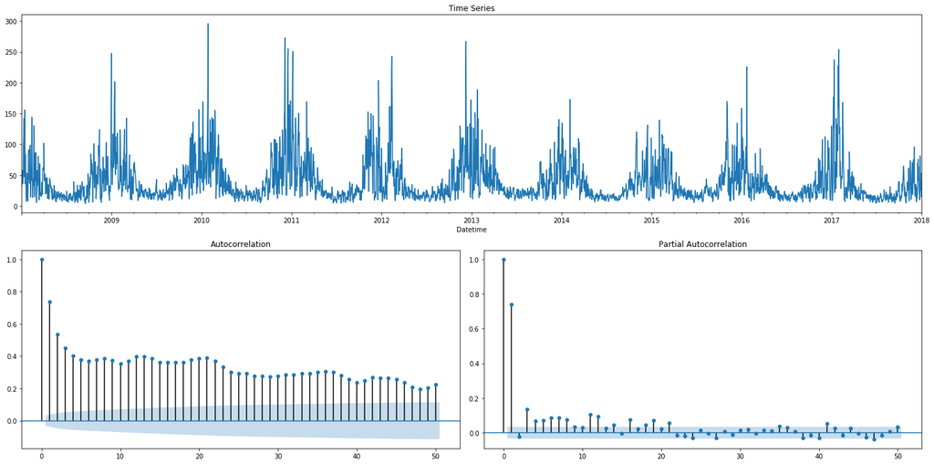

```python
plot_ts_corr(df_train['pm25'])
```

```python
%%time
# Find best parameters (grid-search)
best_results = get_best_arima_params_for_time_series(data=df_train,
                                                     seasonal=False,
                                                     max_param_range_p=5,
                                                     max_param_range_d=0,
                                                     max_param_range_q=5)
```

```python
SARIMAX(0, 0, 0) - AIC:38983.00813026588
SARIMAX(0, 0, 1) - AIC:36059.690659735024
SARIMAX(0, 0, 2) - AIC:34918.45008233713
SARIMAX(0, 0, 3) - AIC:34409.81571434598
SARIMAX(0, 0, 4) - AIC:34096.090358520945
SARIMAX(0, 0, 5) - AIC:33892.384328226864
SARIMAX(1, 0, 0) - AIC:33340.065325479634
SARIMAX(1, 0, 1) - AIC:33319.44543874674
SARIMAX(1, 0, 2) - AIC:32936.30774547422
SARIMAX(1, 0, 3) - AIC:32824.261541303546
SARIMAX(1, 0, 4) - AIC:32809.033323439486
SARIMAX(1, 0, 5) - AIC:32805.637460981045
SARIMAX(2, 0, 2) - AIC:32803.919187166546
SARIMAX(4, 0, 4) - AIC:32803.501675630905
SARIMAX(5, 0, 4) - AIC:32802.877819381196
Best model is ARIMA(5, 0, 4) with AIC of 32802.877819381196
CPU times: user 2min 4s, sys: 19.3 s, total: 2min 23s
Wall time: 36 s
```

```python
%%time
# Train the model -> find best parameters
p = 5 # (AR)
d = 0 # differencing
q = 4 # (MA)
model = SARIMAX(endog=df_train['pm25'], order=(p, d, q))
model_fitted = model.fit()
```

```
CPU times: user 6.32 s, sys: 946 ms, total: 7.26 s
Wall time: 1.8 s
```

```python
model_fitted
```

```
<statsmodels.tsa.statespace.sarimax.SARIMAXResultsWrapper at 0x129663450>
```

```python
# Estimated parameters
print(model_fitted.summary())
```

```
                               SARIMAX Results
==============================================================================
Dep. Variable:                   pm25   No. Observations:                 3653
Model:               SARIMAX(5, 0, 4)   Log Likelihood              -16391.439
Date:                Wed, 10 Jun 2020   AIC                          32802.878
Time:                        13:56:45   BIC                          32864.911
Sample:                    01-02-2008   HQIC                         32824.969
                         - 01-01-2018
Covariance Type:                  opg
==============================================================================
                 coef    std err          z      P>|z|      [0.025      0.975]
------------------------------------------------------------------------------
ar.L1         -0.3715      0.073     -5.101      0.000      -0.514      -0.229
ar.L2          0.9605      0.030     31.914      0.000       0.901       1.019
ar.L3          0.7508      0.075      9.968      0.000       0.603       0.898
ar.L4         -0.2830      0.049     -5.756      0.000      -0.379      -0.187
ar.L5         -0.0621      0.044     -1.405      0.160      -0.149       0.025
ma.L1          1.0806      0.072     15.060      0.000       0.940       1.221
ma.L2         -0.3373      0.049     -6.878      0.000      -0.433      -0.241
ma.L3         -1.0838      0.047    -23.092      0.000      -1.176      -0.992
ma.L4         -0.3354      0.067     -5.038      0.000      -0.466      -0.205
sigma2       463.6061      4.932     94.005      0.000     453.940     473.272
===================================================================================
Ljung-Box (Q):                       90.58   Jarque-Bera (JB):             13882.30
Prob(Q):                              0.00   Prob(JB):                         0.00
Heteroskedasticity (H):               0.67   Skew:                             1.18
Prob(H) (two-sided):                  0.00   Kurtosis:                        12.26
===================================================================================

Warnings:
[1] Covariance matrix calculated using the outer product of gradients (complex-step).
```

```python
# True parameters
print(f'The coefficients of the model are:\n {model_fitted.params}')
```

```
The coefficients of the model are:
 ar.L1      -0.371504
ar.L2       0.960484
ar.L3       0.750789
ar.L4      -0.282962
ar.L5      -0.062102
ma.L1       1.080584
ma.L2      -0.337271
ma.L3      -1.083846
ma.L4      -0.335355
sigma2    463.606131
dtype: float64
```

```python
print(f'The residual errors during training of the model are:\n {model_fitted.resid}')
```

```
The residual errors during training of the model are:
 Datetime
2008-01-02    30.958333
2008-01-03    18.566070
2008-01-04     2.540005
2008-01-05    20.785389
2008-01-06   -13.859405
                ...
2017-12-28   -16.955572
2017-12-29    -2.650204
2017-12-30     2.845236
2017-12-31   -20.204788
2018-01-01    31.557575
Freq: D, Length: 3653, dtype: float64
```

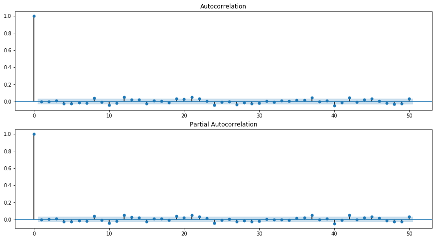

```python
# Evaluate model quality
import statsmodels.api as sm
res = model_fitted.resid
fig,ax = plt.subplots(2,1,figsize=(15,8))
fig = sm.graphics.tsa.plot_acf(res, lags=50, ax=ax[0])
fig = sm.graphics.tsa.plot_pacf(res, lags=50, ax=ax[1])
plt.show();
```